# Reproducible Research: Peer Assessment 1

## Loading and preprocessing the data

```r
data <- read.csv("~/activity.csv")
data <- transform(data, date = as.Date(date, format = "%Y-%m-%d"))
str(data)
```

```
## 'data.frame':    17568 obs. of  3 variables:
##  $ steps   : int  NA NA NA NA NA NA NA NA NA NA ...
##  $ date    : Date, format: "2012-10-01" "2012-10-01" ...
##  $ interval: int  0 5 10 15 20 25 30 35 40 45 ...
```

## What is mean total number of steps taken per day?

### 2.1 Histogram

Total number of steps taken per day was calculated.

```r
totalNSteps <- aggregate(data$step, list(Day = data$date), sum, na.rm = T )
```

Figure 1 shows distribution of total number of steps taken per day for this person.

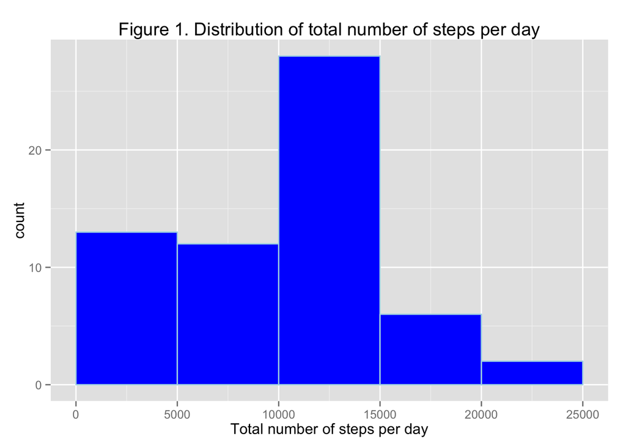

```r
ggplot(totalNSteps, aes(x)) +
  geom_histogram(breaks = seq(0, 25000, 5000), binwidth = 3000, fill = "blue", color = "light blue") +
  xlab("Total number of steps per day") +
  ggtitle("Figure 1. Distribution of total number of steps per day")
```

### 2.2 Mean & Median

```r
meanTotalNSteps <- mean(totalNSteps$x)
medianTotalNSteps <- median(totalNSteps$x)
```

**Mean** and **median** total number of steps taken per day were **9354.2295** and **10395**, respectively.

## What is the average daily activity pattern?

### 3.1 Trend of daily activity

In this part, mean number of steps across all days in 5-minute intervals was calculated.

```r
dailyAct <- aggregate(data$steps, list(Interval = data$interval), mean, na.rm = T)
```

Figure 2 shows the trend of mean number of steps for 5-minute intervals across all days.

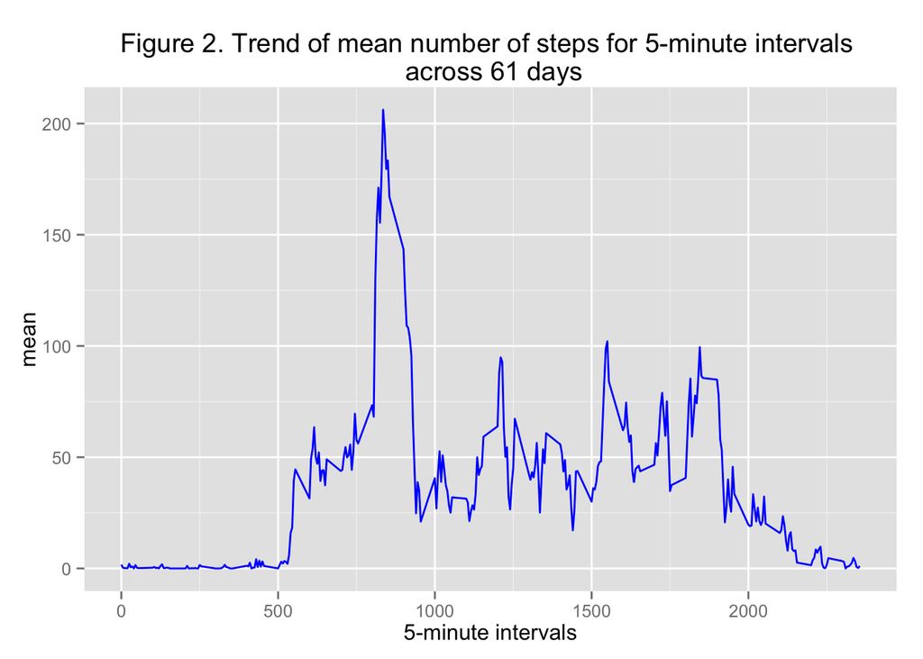

```r
ggplot(dailyAct, aes(Interval, x)) +
  geom_line(color = "blue") +
  xlab("5-minute intervals") +
  ylab("mean") +
  ggtitle("Figure 2. Trend of mean number of steps for 5-minute intervals \n across 61 days")
```

### 3.2 Maximum activity time

In order to figure out the busiest time of day for this person, maximum number of steps across intervals was calculated.

```r
d <- dailyAct[which.max(dailyAct$x),]
```

Result shows that the subject was mostly activated at interval with identifier **835** (8 to 9 AM) during these two months.

## Imputing missing values

### 4.1 Number of missing values

```r
na <- is.na(data$steps)
nas <- sum(na)
```

Number of missing values is **2304**.

### 4.2 Missing values imputation

To increase accuracy of results, missing values were imputed with using mean for that 5-minute interval.

```r
step <- numeric()
for(i in 1:nrow(data)){
  if(na[i]){
    step[i] = dailyAct$x[dailyAct$Interval == data$interval[i]]
  }else{
    step[i] = data$steps[i]
  }
}
```

### 4.3 New dataset

New dataset was created with *date* and *interval* variables from original dataset and *steps* from imputed vector.

```r
newData <- data.frame(steps = step, date = data$date, interval = data$interval)
```

### 4.4 Summary of new dataset

Histogram (figure 3) as well as mean and median of the total number of steps taken each day were evaluated with using imputed dataset.

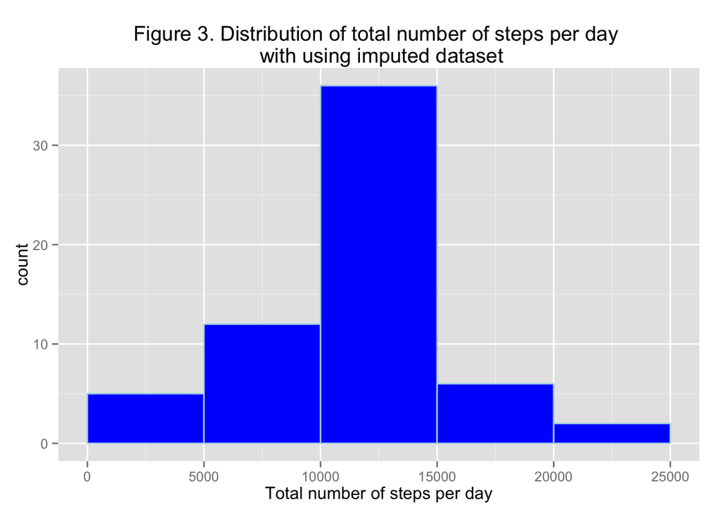

```r
#calculate total number of steps per each day with using imputed dataset
totalNSteps <- aggregate(newData$step, list(Day = newData$date), sum)

#Histogram of total number of steps per each day with using imputed dataset
ggplot(totalNSteps, aes(x)) +
  geom_histogram(breaks = seq(0, 25000, 5000), binwidth = 3000, fill = "blue", color = "light blue") +
  xlab("Total number of steps per day") +
  ggtitle("Figure 3. Distribution of total number of steps per day \n with using imputed dataset")
```

Comparison of figure 1 and 3 confirmed the impact of missing values on statistical inference. Distribution of total number of steps per day with using original dataset was nearly skewed (figure 1), whereas this was almost bell shaped with using imputed dataset (figure 3)

```r
#Mean and Median of total number of steps per day with using imputed dataset
newMeanTotalNSteps <- mean(totalNSteps$x)
newMedianTotalNSteps <- median(totalNSteps$x)
```

**Mean** and **median** total number of steps taken per day were **1.0766 × 10<sup>4</sup>** and **1.0766 × 10<sup>4</sup>**, respectively. Comparison of new value of **mean** and **median** with previous results (mean = **9354.2295** and median = **10395**) shows that **median** is more robust statistics than **mean**.

## Are there differences in activity patterns between weekdays and weekends?

For this section, a new factor variable was created to distinguish weekdays from weekends.

```r
newData$weekId <- format(newData$date, "%u")
newData[newData$weekId %in% as.character(c(1:5)), ]$weekId = "weekday"
newData[newData$weekId %in% as.character(c(6, 7)), ]$weekId = "weekend"
newData$weekId <- as.factor(newData$weekId)
```

Activity patterns between weekdays and weekends were shown in figure 4

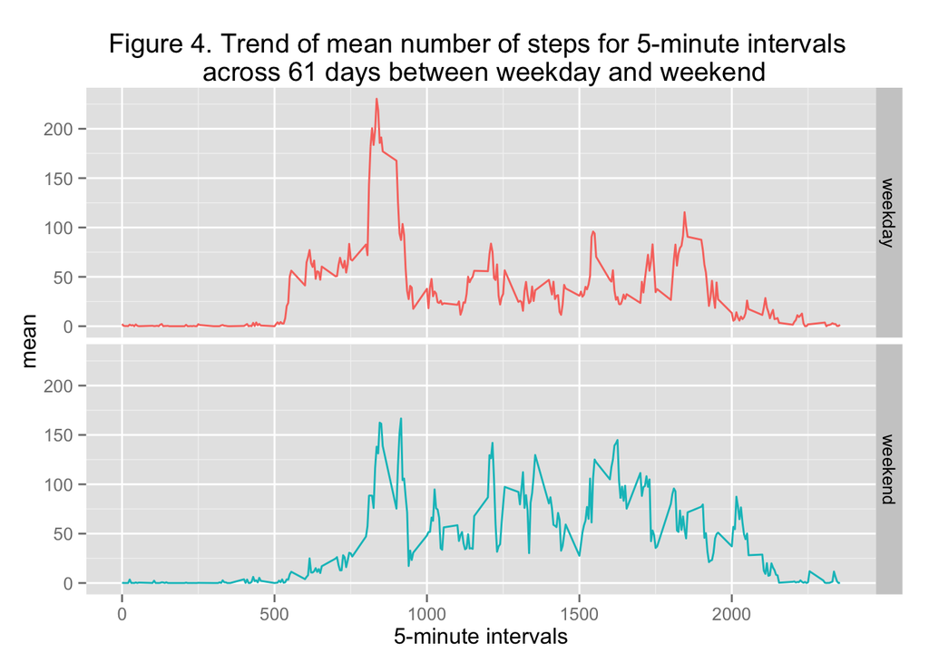

```r
#mean number of steps across all days in 5-minute intervals
dailyAct <- aggregate(newData$steps, list(Interval = newData$interval, Week = newData$weekId), mean, na.rm = T)

#Plot mean number of steps across all days in 5-minute intervals between weekday and weekend
ggplot(dailyAct, aes(Interval, x)) +
  geom_line(aes(color = Week)) +
  facet_grid(Week~.) +
  xlab("5-minute intervals") +
  ylab("mean") +
  ggtitle("Figure 4. Trend of mean number of steps for 5-minute intervals \n across 61 days between weekday and weekend") +
  theme(legend.position = "none")
```

As figure 4 shows the subject was more activated in weekday mornings (goes to work) than weekend mornings (surprise!). In contrast, the subject more active in weekend afternoons (shopping, …) than weekday afternoons. In conclusion, the subject’s gender might be **female**.